Skip to content

# Gene Search

We highly that users visit our [DISCO](http://www.immunesinglecell.org/) website to access the web-based application for an enhanced and interactive gene search experience.

In addition, researchers can utilize the `gene_search` function available in the `DISCOtoolkit` Python library. This function provides a convenient approach to visualize gene expression values for the gene of interest. By leveraging the capabilities of Python, it simplifies the data exploration process, offering users greater efficiency and flexibility.

By utilizing both the web-based application and the `gene_search` function, users can gain valuable insights into gene expression profiles and analyze their data using complementary approaches. Researchers are encouraged to select the method that aligns best with their preferences and research requirements.

```python
# for google colab
# pip install discotoolkit
# first import the installed package
import discotoolkit as dt

# adding ignore warning to clean the code
import warnings

# Ignore all warnings
warnings.filterwarnings('ignore')
```

# for google colab # pip install discotoolkit # first import the installed package import discotoolkit as dt # adding ignore warning to clean the code import warnings # Ignore all warnings warnings.filterwarnings('ignore')

Optional

The `atlas` argument is optional for the `gene_search` function

```python
# get all the altas from disco in case the user want to check only for selected atlas.
all_atlas = dt.get_atlas()
```

# get all the altas from disco in case the user want to check only for selected atlas. all_atlas = dt.get_atlas()

The `gene_search` function only requires one argument: the gene name. For example, to search for the "LYVE1" gene, use the following syntax:

```python
dt.gene_search("LYVE1")
```

dt.gene_search("LYVE1")

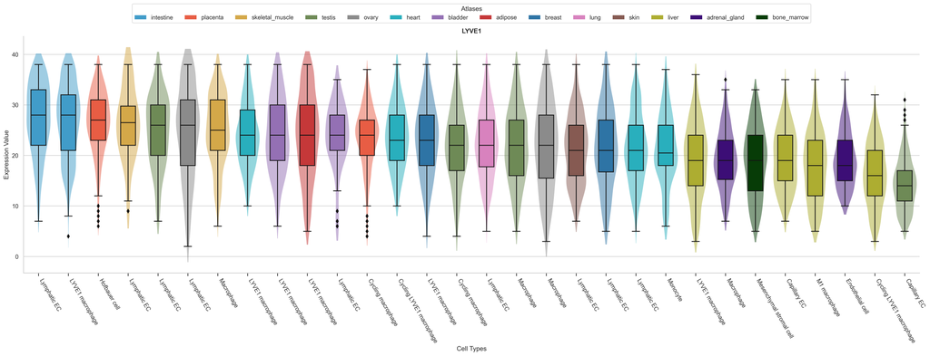

To search for specific atlas, the input for `atlas` argument can either be a string or list of string as follow:

```python
# string only
dt.gene_search("LYVE1", atlas="intestine")
```

# string only dt.gene_search("LYVE1", atlas="intestine")

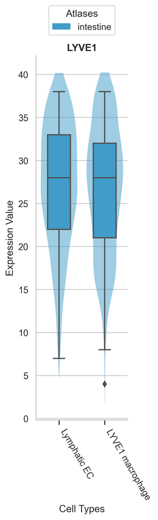

```python
# list of string
dt.gene_search("LYVE1", atlas=["lung", "intestine"])
```

# list of string dt.gene_search("LYVE1", atlas=["lung", "intestine"])

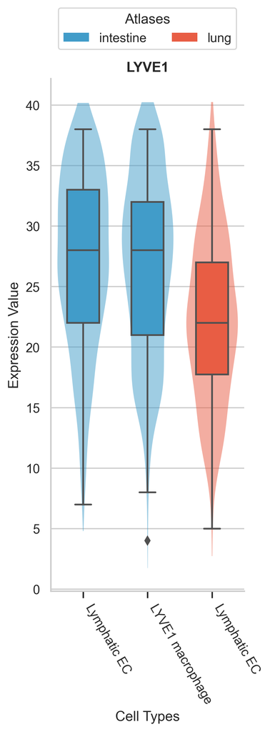

Other optional arguments: `figsize` and `dpi`, are mainly use for adjusting the figure for ease of use.

For example:

```python
# changing from 300 to 100 dpi
dt.gene_search("LYVE1", atlas="intestine", dpi = 100)
```

# changing from 300 to 100 dpi dt.gene_search("LYVE1", atlas="intestine", dpi = 100)

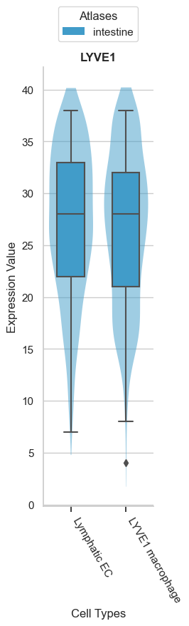

```python
# changing from 300 to 100 dpi and adjusting the figure
dt.gene_search("LYVE1", atlas="intestine", figsize= (2, 9), dpi = 100)
```

# changing from 300 to 100 dpi and adjusting the figure dt.gene_search("LYVE1", atlas="intestine", figsize= (2, 9), dpi = 100)

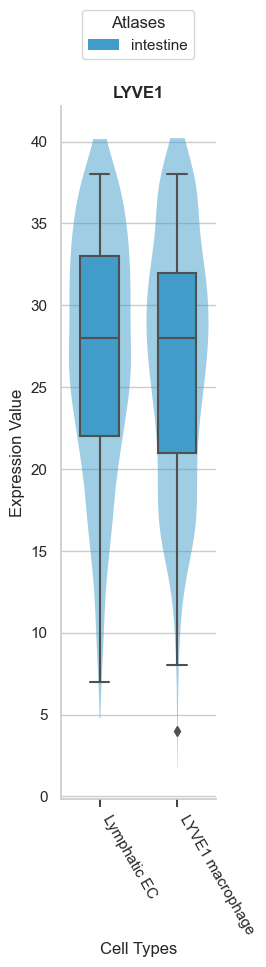

Last update: October 24, 2024  
Created: May 19, 2023